# High Inflation Item Analysis

Erik Dean

02/16/2022

## Description

This RMD will look in some detail at the items that have had unusually high price changes in the pandemic.

## Data

The following code (not shown in markdown) will import and format the BEA data from csv tables. All of this is duplicated from Wavelet Analysis of Variance v2.

### Query the Data

The following function (not shown in markdown) allows querying the main tables (exp, qua, and pri) based on item levels, where goods and services are level 1; durable goods, nondurable goods, and HH cons exp on services are level 2; and so on. Often, we’ll want the lowest (i.e. most granular level), which can be retrieved with the lowestLevel = T parameter. This is the same as in Process PCE Data.Rmd

## Build Data

This will build the itemClass table that’s the same in Wavelet Analysis of Variance v2.RMD.

- Note, I’m skipping the energy analysis here, which has a start date in 1989. The WaveletAnalysis of Variance v.2.RMD has an errot, in that it sets the start date to 1983, but uses the original 1989 priSeries &c. data frames. The two start dates give different numbers of series, so they don’t actually work together.

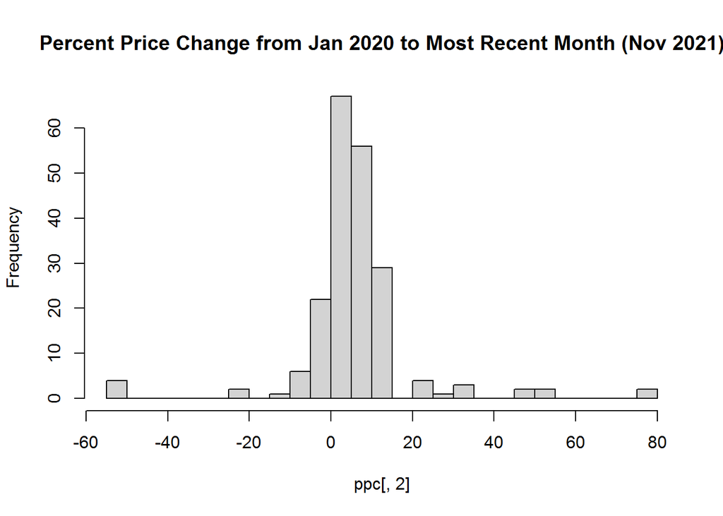

```
##                                                     Item Pan.Price.Pct.Chg
## 97    Less: Personal remittances in kind to nonresidents          12.44174
## 11                                             Furniture          12.68718
## 154                                        Pension funds          12.69235
## 3                                       New light trucks          12.76665
## 92                                         Tobacco (127)          13.05817
## 95             Government employees' expenditures abroad          13.40133
## 96                Private employees' expenditures abroad          13.40145
## 50                                               Poultry          14.88862
## 48                                                  Pork          20.50268
## 15                            Major household appliances          21.90615
## 66               Food produced and consumed on farms (6)          24.17428
## 75                                              Fuel oil          24.20154
## 47                                         Beef and veal          27.04562
## 107                                     Natural gas (28)          32.55022
## 73                         Gasoline and other motor fuel          33.25851
## 76                                           Other fuels          33.90403
## 7                        Net transactions in used trucks          47.58872
## 4                         Net transactions in used autos          47.58888
## 6                                 Employee reimbursement          50.79947
## 118                                 Motor vehicle rental          50.80002
## 8                                      Used truck margin          79.83953
## 5                                       Used auto margin          79.84207
## NA                                                  <NA>                NA
## NA.1                                                <NA>                NA
## NA.2                                                <NA>                NA
## NA.3                                                <NA>                NA
## NA.4                                                <NA>                NA
## NA.5                                                <NA>                NA
## NA.6                                                <NA>                NA
## NA.7                                                <NA>                NA
## NA.8                                                <NA>                NA
## NA.9                                                <NA>                NA
## NA.10                                               <NA>                NA
## NA.11                                               <NA>                NA
## NA.12                                               <NA>                NA
## NA.13                                               <NA>                NA
## NA.14                                               <NA>                NA
## NA.15                                               <NA>                NA
```

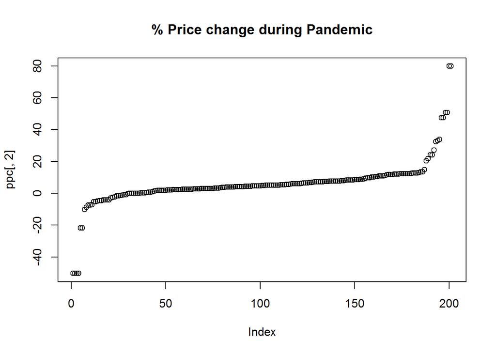

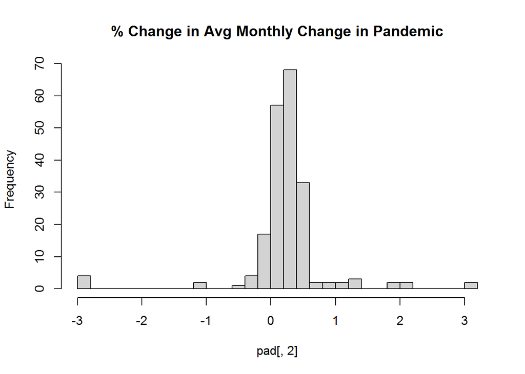

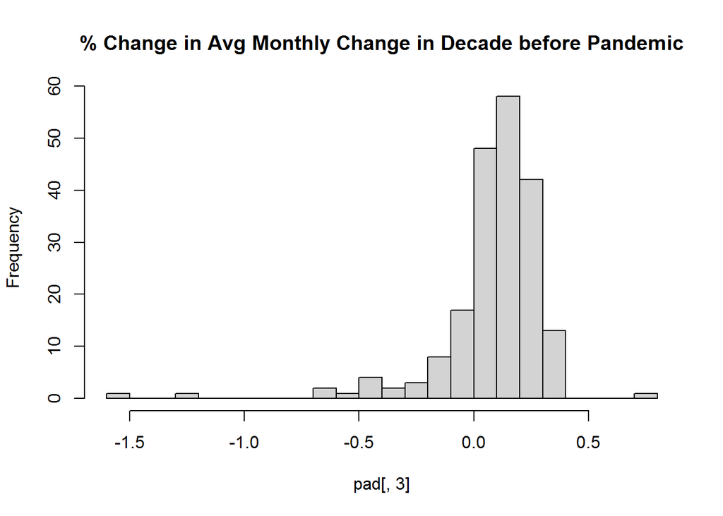

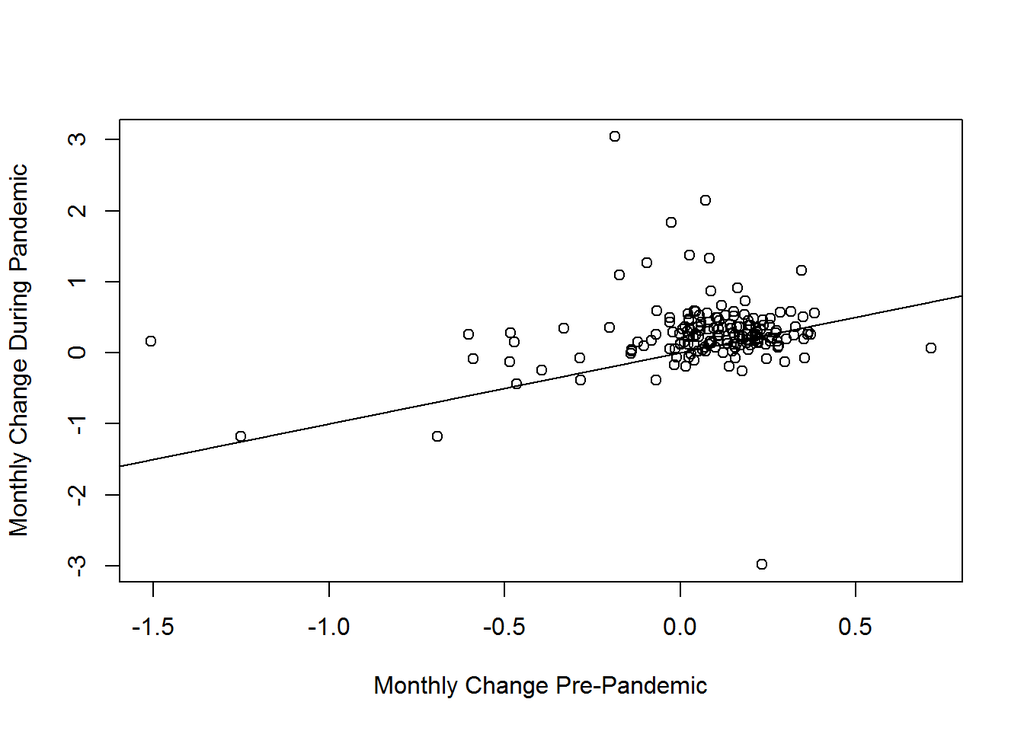

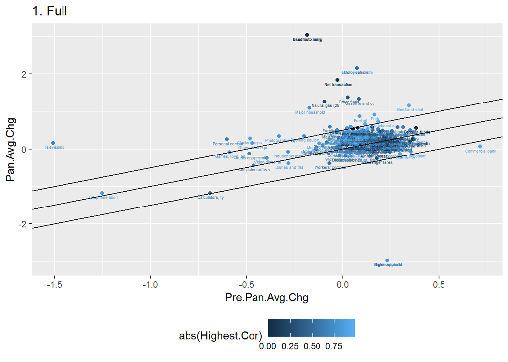

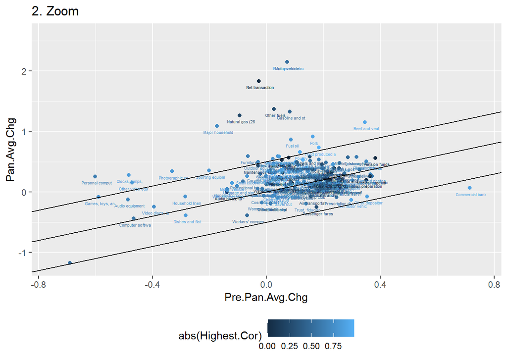

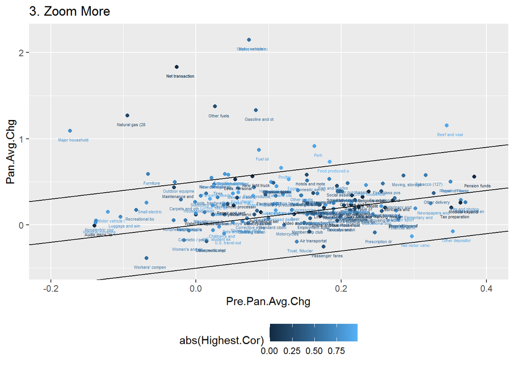

As a first pass, I want to grab only those items whose pandemic average monthly percentage price change was 0.5 above the average in the decade prior to the pandemic. Here they are, including the wavelet correlation (P & Q) for the first detail (2-4 months).

```
##                                                                       Item
## 57                                                Games, toys, and hobbies
## 142                                                 Photographic equipment
## 128                                                  Other video equipment
## 138                    Personal computers/tablets and peripheral equipment
## 179                                                            Televisions
## 164                                                 Securities commissions
## 172        Sporting equipment, supplies, guns, and ammunition (part of 80)
## 18  Clocks, lamps, lighting fixtures, and other household decorative items
## 129                                         Outdoor equipment and supplies
## 109                                                     New domestic autos
## 110                                                      New foreign autos
## 56                                                               Furniture
## 60                               Government employees' expenditures abroad
## 149                                 Private employees' expenditures abroad
```

[output cut: 45 more lines]

Here are the Continuous Wavelet Transform plots for those items.

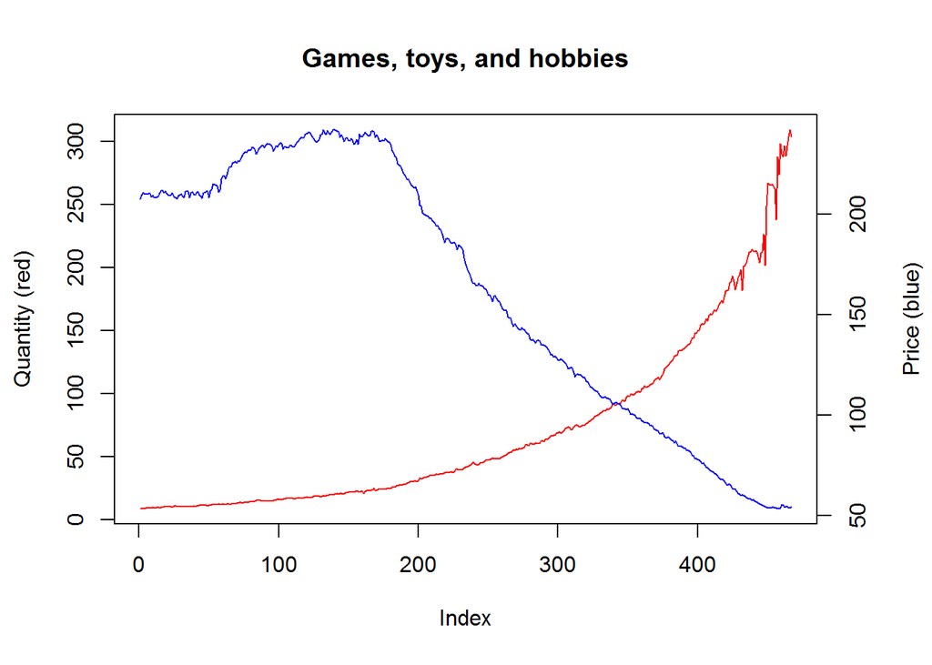

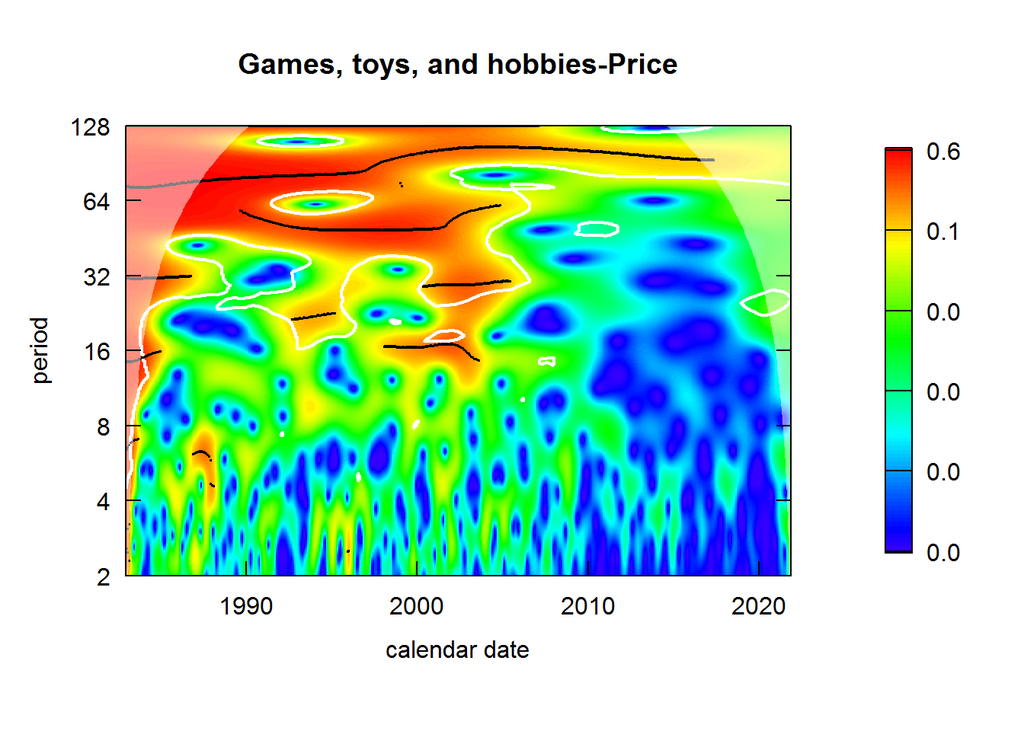

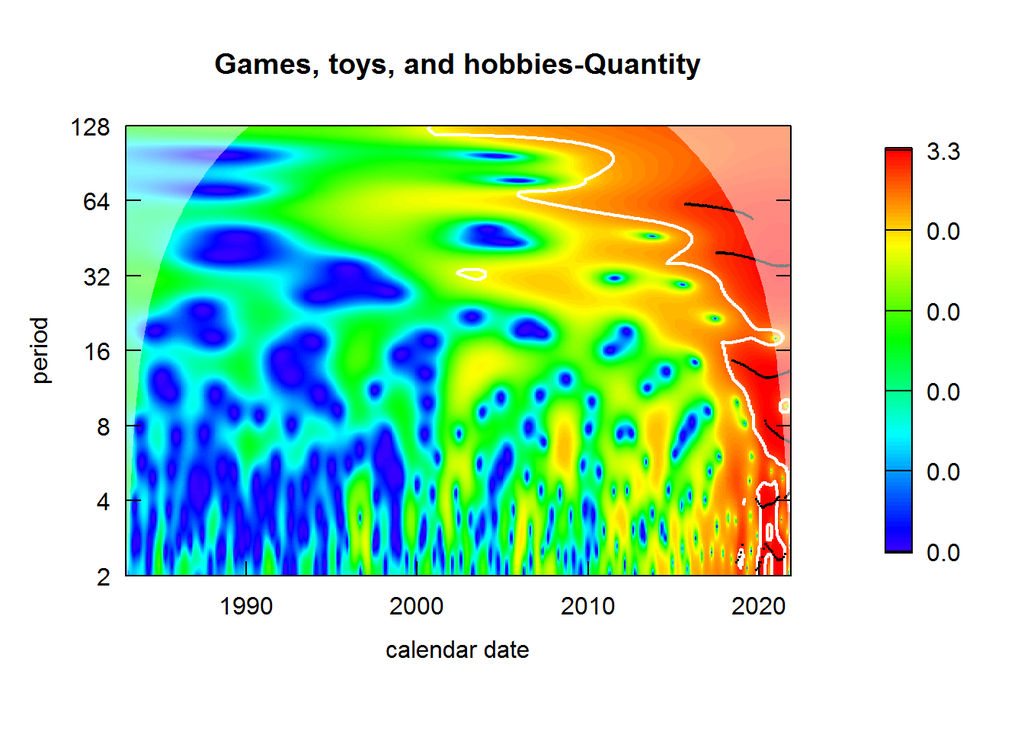

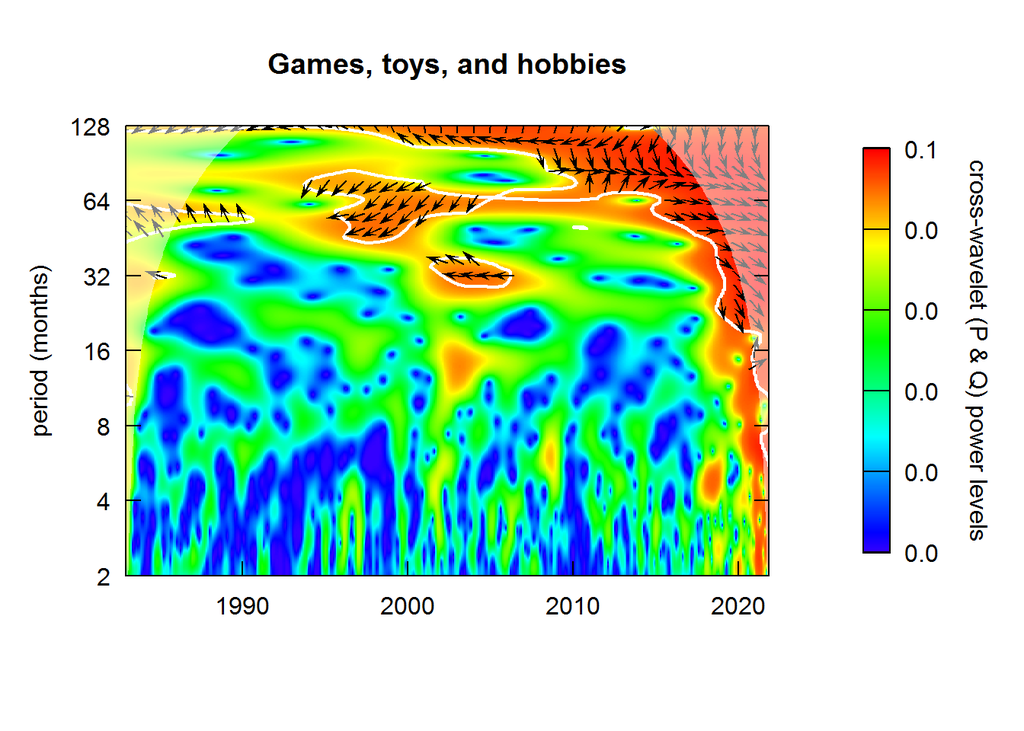

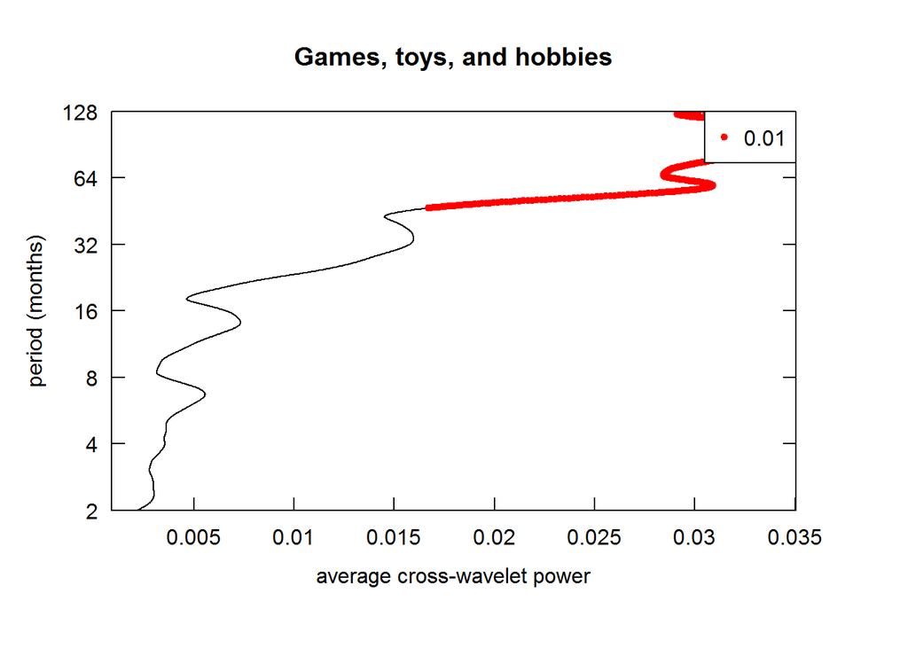

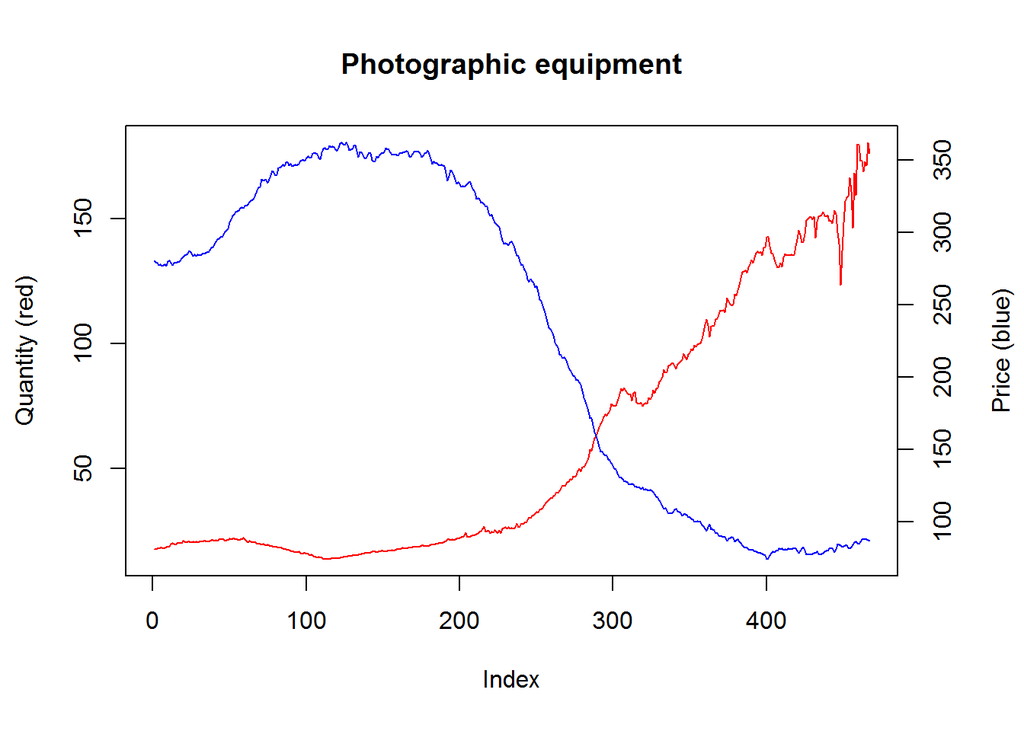

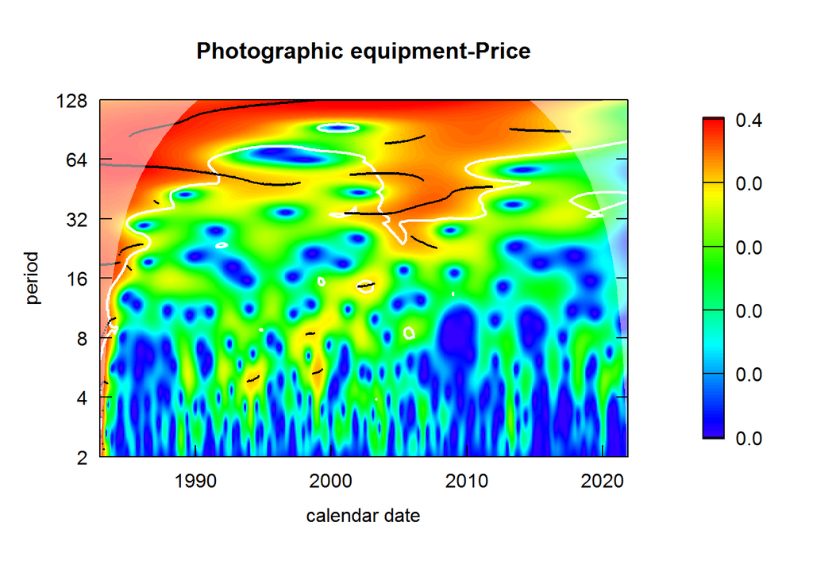

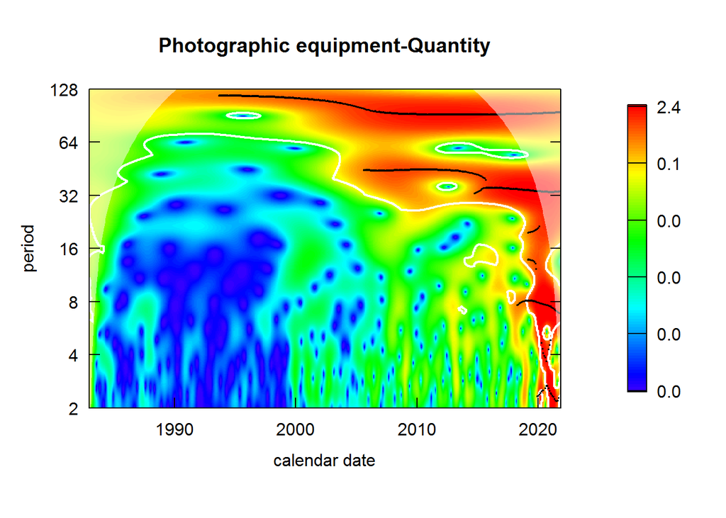

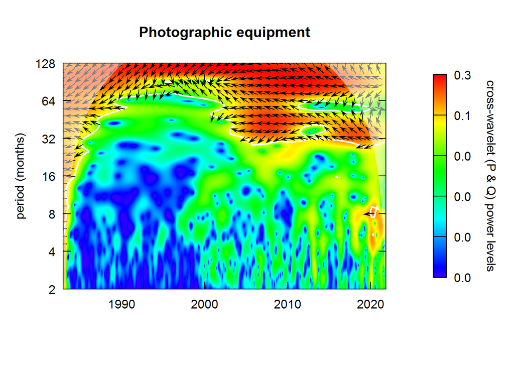

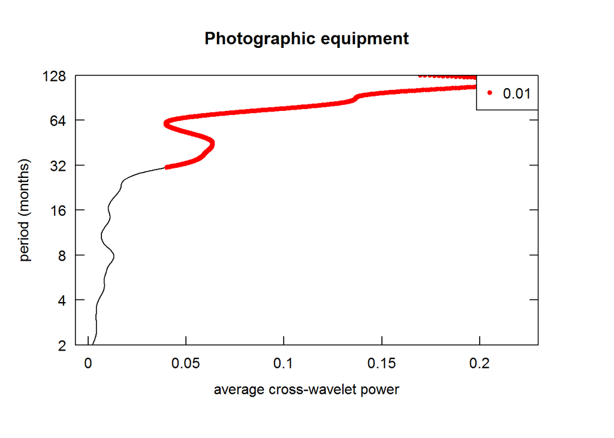